# Data Visualization #1 - House Prices

Febrio Akbar

### Library

```r
library(tidyverse)
library(gghighlight)
library(patchwork)
```

### About Dataset

Downloaded from Kaggle : https://www.kaggle.com/c/house-prices-advanced-regression-techniques

The Ames Housing dataset was compiled by Dean De Cock for use in data science education. It’s an incredible alternative for data scientists looking for a modernized and expanded version of the often cited Boston Housing dataset.

Ask a home buyer to describe their dream house, and they probably won’t begin with the height of the basement ceiling or the proximity to an east-west railroad. But this playground competition’s dataset proves that much more influences price negotiations than the number of bedrooms or a white-picket fence.

With 79 explanatory variables describing (almost) every aspect of residential homes in Ames, Iowa, this competition challenges you to predict the final price of each home.

```r
df = read_csv('train.csv')
df = tbl_df(df)
df
```

```
## # A tibble: 1,460 x 81
##       Id MSSubClass MSZoning LotFrontage LotArea Street Alley LotShape
##    <dbl>      <dbl> <chr>          <dbl>   <dbl> <chr>  <chr> <chr>
##  1     1         60 RL                65    8450 Pave   <NA>  Reg
##  2     2         20 RL                80    9600 Pave   <NA>  Reg
##  3     3         60 RL                68   11250 Pave   <NA>  IR1
##  4     4         70 RL                60    9550 Pave   <NA>  IR1
##  5     5         60 RL                84   14260 Pave   <NA>  IR1
##  6     6         50 RL                85   14115 Pave   <NA>  IR1
##  7     7         20 RL                75   10084 Pave   <NA>  Reg
##  8     8         60 RL                NA   10382 Pave   <NA>  IR1
##  9     9         50 RM                51    6120 Pave   <NA>  Reg
## 10    10        190 RL                50    7420 Pave   <NA>  Reg
## # ... with 1,450 more rows, and 73 more variables: LandContour <chr>,
## #   Utilities <chr>, LotConfig <chr>, LandSlope <chr>, Neighborhood <chr>,
## #   Condition1 <chr>, Condition2 <chr>, BldgType <chr>, HouseStyle <chr>,
## #   OverallQual <dbl>, OverallCond <dbl>, YearBuilt <dbl>, YearRemodAdd <dbl>,
## #   RoofStyle <chr>, RoofMatl <chr>, Exterior1st <chr>, Exterior2nd <chr>,
## #   MasVnrType <chr>, MasVnrArea <dbl>, ExterQual <chr>, ExterCond <chr>,
## #   Foundation <chr>, BsmtQual <chr>, BsmtCond <chr>, BsmtExposure <chr>, ...
```

### Variable name and type in Dataset

```r
glimpse(df)
```

```
## Rows: 1,460
## Columns: 81
## $ Id            <dbl> 1, 2, 3, 4, 5, 6, 7, 8, 9, 10, 11, 12, 13, 14, 15, 16, 1~
## $ MSSubClass    <dbl> 60, 20, 60, 70, 60, 50, 20, 60, 50, 190, 20, 60, 20, 20,~
## $ MSZoning      <chr> "RL", "RL", "RL", "RL", "RL", "RL", "RL", "RL", "RM", "R~
## $ LotFrontage   <dbl> 65, 80, 68, 60, 84, 85, 75, NA, 51, 50, 70, 85, NA, 91, ~
## $ LotArea       <dbl> 8450, 9600, 11250, 9550, 14260, 14115, 10084, 10382, 612~
## $ Street        <chr> "Pave", "Pave", "Pave", "Pave", "Pave", "Pave", "Pave", ~
## $ Alley         <chr> NA, NA, NA, NA, NA, NA, NA, NA, NA, NA, NA, NA, NA, NA, ~
## $ LotShape      <chr> "Reg", "Reg", "IR1", "IR1", "IR1", "IR1", "Reg", "IR1", ~
## $ LandContour   <chr> "Lvl", "Lvl", "Lvl", "Lvl", "Lvl", "Lvl", "Lvl", "Lvl", ~
## $ Utilities     <chr> "AllPub", "AllPub", "AllPub", "AllPub", "AllPub", "AllPu~
## $ LotConfig     <chr> "Inside", "FR2", "Inside", "Corner", "FR2", "Inside", "I~
## $ LandSlope     <chr> "Gtl", "Gtl", "Gtl", "Gtl", "Gtl", "Gtl", "Gtl", "Gtl", ~
## $ Neighborhood  <chr> "CollgCr", "Veenker", "CollgCr", "Crawfor", "NoRidge", "~
```

[output cut: 68 more lines]

### Check Missing Value

```r
colSums(is.na(df))
```

```
##            Id    MSSubClass      MSZoning   LotFrontage       LotArea
##             0             0             0           259             0
##        Street         Alley      LotShape   LandContour     Utilities
##             0          1369             0             0             0
##     LotConfig     LandSlope  Neighborhood    Condition1    Condition2
##             0             0             0             0             0
##      BldgType    HouseStyle   OverallQual   OverallCond     YearBuilt
##             0             0             0             0             0
##  YearRemodAdd     RoofStyle      RoofMatl   Exterior1st   Exterior2nd
##             0             0             0             0             0
##    MasVnrType    MasVnrArea     ExterQual     ExterCond    Foundation
##             8             8             0             0             0
##      BsmtQual      BsmtCond  BsmtExposure  BsmtFinType1    BsmtFinSF1
##            37            37            38            37             0
##  BsmtFinType2    BsmtFinSF2     BsmtUnfSF   TotalBsmtSF       Heating
##            38             0             0             0             0
##     HeatingQC    CentralAir    Electrical      1stFlrSF      2ndFlrSF
##             0             0             1             0             0
##  LowQualFinSF     GrLivArea  BsmtFullBath  BsmtHalfBath      FullBath
##             0             0             0             0             0
##      HalfBath  BedroomAbvGr  KitchenAbvGr   KitchenQual  TotRmsAbvGrd
##             0             0             0             0             0
##    Functional    Fireplaces   FireplaceQu    GarageType   GarageYrBlt
##             0             0           690            81            81
##  GarageFinish    GarageCars    GarageArea    GarageQual    GarageCond
##            81             0             0            81            81
##    PavedDrive    WoodDeckSF   OpenPorchSF EnclosedPorch     3SsnPorch
##             0             0             0             0             0
##   ScreenPorch      PoolArea        PoolQC         Fence   MiscFeature
##             0             0          1453          1179          1406
##       MiscVal        MoSold        YrSold      SaleType SaleCondition
##             0             0             0             0             0
##     SalePrice
##             0
```

## 1. Count of one categorical feature

Lot Configuration is a variable that state type of configuration of each house.

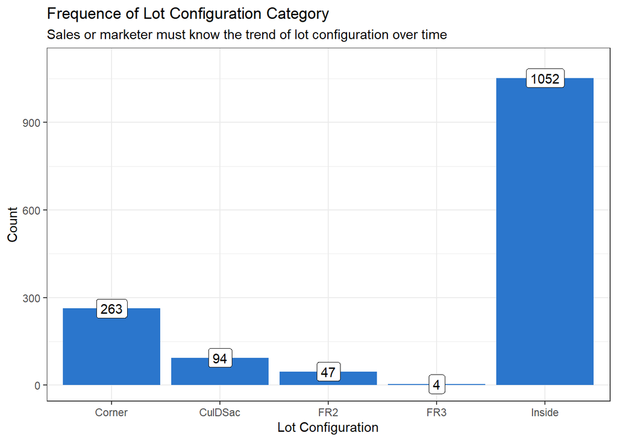

```r
df %>%
  group_by(LotConfig) %>%
  summarise(nbrow=n()) %>%
  ggplot(aes(x = LotConfig,y=nbrow))+
  coord_cartesian(ylim=c(0,1100))+
  geom_bar(stat='identity',fill = "#2B76CC")+
  geom_label(aes(label=nbrow))+
  labs(title =  'Frequence of Lot Configuration Category',subtitle = 'Sales or marketer must know the trend of lot configuration over time', x ='Lot Configuration', y='Count')+theme_bw()
```

The bar chart show us that the most used lot configuration type by far is inside type and the rarest is FR3 with just 4 data.

## 2. Distribution of one continuous feature

[figure not shown]

```r
df %>%
  ggplot(aes(x = YearBuilt)) +
  geom_density(color="red", fill="lightblue")+
  labs(title = 'Sale Price distibution Density',
  subtitle = 'The graph show saleprice distribution desity since before 20th century until over than 1980s',
  x = 'Sale Price')+theme_bw()
```

## 3. Categorical-continuous

*Categorical = Sale Condition* Continous = Sale Price

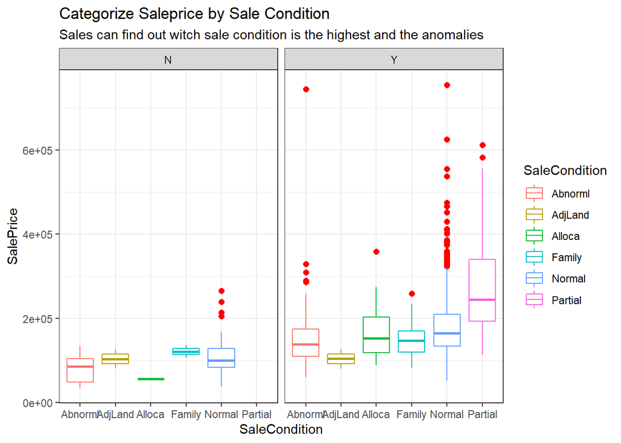

```r
df %>%
  ggplot(aes(x = SaleCondition, y = SalePrice, color=SaleCondition)) +
  geom_boxplot(notch=FALSE,outlier.colour="red",outlier.size=2)+
  labs(title = 'Categorize Saleprice by Sale Condition',
  subtitle = 'Sales can find out witch sale condition is the highest and the anomalies')+
  theme(axis.text.x = element_text(angle = 90, vjust = 0.5, hjust=1))+
  facet_grid(. ~ CentralAir)+theme_bw()
```

From the boxplot we know that partial sale condition is the overall highest but the normal condition have outlier more than the others

## 4. Continuous - Continuous

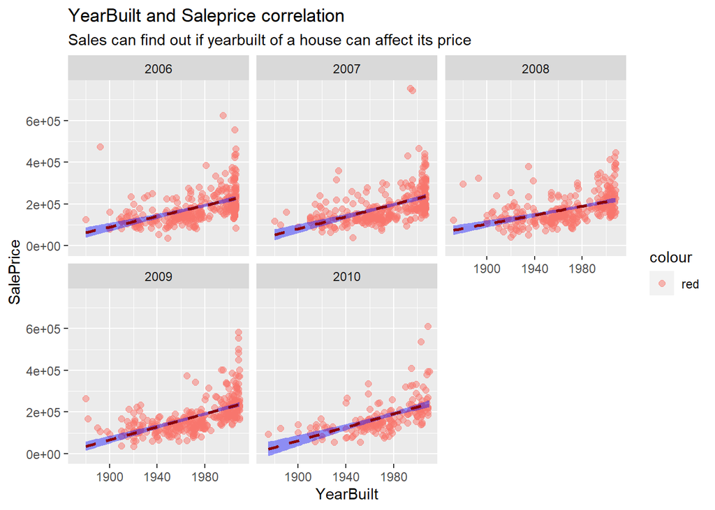

```r
df %>%
  ggplot(aes(x = YearBuilt, y = SalePrice, col='red')) +
  geom_point(alpha=0.5, size=2) +
  geom_smooth(formula = y ~ x,method='lm',  linetype="dashed",
             color="darkred", fill="blue")+
  labs(title = 'YearBuilt and Saleprice correlation',
  subtitle = 'Sales can find out if yearbuilt of a house can affect its price')+
   facet_wrap(~YrSold)
```

From the scatterplot we know that yearbuilt is affecting the saleprice with positive correlation, so the oldest the house than the price will be cheaper.